# Sonderthemen zu Resilienz: OT und KI

Cyber Security Management · Termin 9

Prof. Dr. Dirk Loomans

Hochschule Mainz · dirk.loomans@hs-mainz.de

## Agenda

- Rückblick
- Gastvortrag Thomas Gronenwald (KPMG): Product & Production Security (OT)
- OT-Resilienz im Überblick
- KI-Resilienz
  - Bedrohungen für KI-Systeme
  - Prinzipien der KI-Resilienz
  - Resilienz gegen Daten-Poisoning
  - Wallet DoS – Schutz vor finanziellen API-Angriffen
- Übung Gandalf AI
- Ausblick

## Gastvortrag

**Thomas Gronenwald**, Partner, Head of Product & Production Security, KPMG

War Stories aus der Praxis: Product & Production Security (OT)

## Was ist OT?

- Operational Technology steuert physische Prozesse: Produktion, Energie, Wasser, Verkehr, Medizintechnik, Gebäudetechnik.
- IT verarbeitet Daten – OT bewegt Roboter, öffnet Ventile, schaltet Signale.
- IT/OT-Konvergenz: früher getrennte Netze sind heute über Fernwartung, IIoT und Cloud vernetzt.

## IT vs. OT

Ein Sicherheitsupdate, das eine Maschine sekundenlang stoppt, kann gefährlicher sein als eine bekannte Schwachstelle.

|  | IT | OT |
| --- | --- | --- |
| Prioritäten | Confidentiality – Integrity – Availability | Safety – Availability – Integrity – Confidentiality |
| Lebensdauer | 3–5 Jahre | 10–30 Jahre |
| Wartungsfenster | häufig | selten |
| Philosophie | „Patch early“ | „Change as little as possible“ |
| Echtzeit | Verzögerung tolerierbar | Millisekunden zählen |

## Safety – Security – Resilience

- **Safety:** Schutz von Menschen und Umwelt vor Fehlfunktionen
- **Security:** Schutz vor Cyberangriffen und Manipulation
- **Resilience:** Weiterarbeiten oder schnelle Erholung

Safety darf durch Security nicht gefährdet werden. OT-Resilienz = Schutz ohne Beeinträchtigung des physischen Betriebs.

## Das Purdue-Modell (ISA-95)

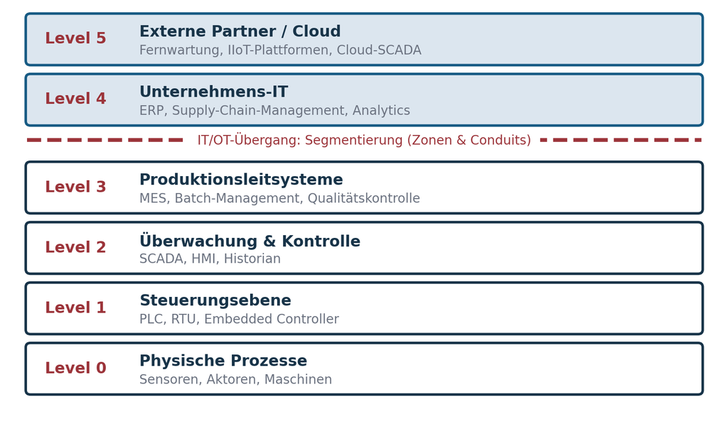

## Bedrohungen in OT

- Ransomware in der IT macht OT unbedienbar (HMIs, Engineering-Workstations, MES)
- Supply Chain: manipulierte Firmware, infizierte Wartungslaptops (Stuxnet)
- Fernwartungszugänge mit Standardpasswörtern
- Manipulation von Steuerlogik und Safety-Systemen (Triton/Trisis)
- IT→OT-Pfad: Colonial Pipeline 2021 – Angriff in der IT, OT vorsorglich gestoppt

## OT-Resilienzmaßnahmen

- Segmentierung nach Zonen & Conduits (IEC 62443)
- Jump Hosts, MFA, zeitlich begrenzte Wartungsfenster statt Dauer-VPN
- Passives OT-Monitoring, Integritätsprüfung von PLC-Programmen
- Patchen nach Test und Risikoabwägung, kompensierende Maßnahmen
- Offline-Backups von PLC-, SCADA-, HMI- und Safety-Konfigurationen
- Wiederanlauf planen: Cold, Warm, Hot Start – Wiedereinschalten ist riskanter als Abschalten

## KI-Resilienz – bekannte Prinzipien in einem neuen Umfeld

- Warum Resilienz auch für KI wichtig ist: KI schafft neue Abhängigkeiten; ein Neustart behebt manipulierte Daten nicht.
- Herausforderungen: Daten- und Prompt-Poisoning, Verfügbarkeit, Bias
- Ziel der Einheit: verstehen, wie wir KI-Systeme resilienter machen können

## Bedrohungen für KI-Systeme

- **Daten-Poisoning:** Manipulation der Trainingsdaten
- **Prompt-Poisoning:** Beeinflussung von Eingabeaufforderungen bei generativen Modellen
- **Bias und Fairness-Probleme:** verzerrte Ergebnisse durch einseitige Daten
- **Verfügbarkeitsangriffe:** DDoS auf KI-basierte Dienste
- **Model Drift:** schleichende Veränderung der Datenmuster
- **Wallet DoS**

## Prinzipien der KI-Resilienz

- **Verifikation und Validierung:** stetige Überprüfung der Trainingsdaten und Modelle
- **Redundanz und Diversität:** unterschiedliche Modelle und Datenquellen
- **Transparenz:** nachvollziehbare Entscheidungswege
- **Adversarial Testing:** gezielte Angriffe simulieren
- **Kontinuierliches Monitoring:** Ausgaben beobachten, Anomalien und Verzerrungen früh erkennen
- **Bias-Reduktion** · **Human in the Loop** · **Recovery** auf definierte Modellzustände

## Fallbeispiel – Resilienz gegen Daten-Poisoning

- Wie kann ein Angreifer Trainingsdaten manipulieren?
- Maßnahmen: Datenvalidierung, robuste Algorithmen, regelmäßige Audits

OT-Beispiel: Manipulierte Vibrationsdaten → KI erkennt keinen Lagerschaden → Totalausfall.

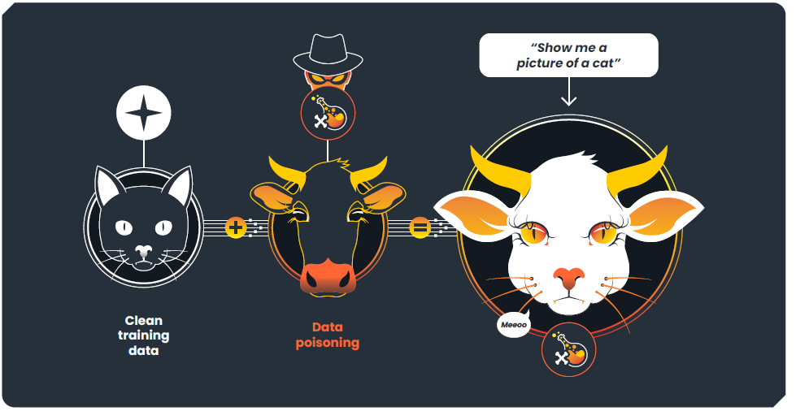

## Wallet DoS – Schutz vor finanziellen API-Angriffen

**Was ist Wallet DoS?** Ein Angriff, bei dem durch übermäßige API-Nutzung Credits oder Guthaben eines Dienstanbieters aufgebraucht werden.

**Risiko:** nicht nur technischer, sondern auch finanzieller Schaden für den Betreiber.

**Gegenmaßnahmen**

- mandantenspezifische API-Schlüssel
- Rate Limits und Monitoring pro Mandant
- separate Budgets pro Mandant

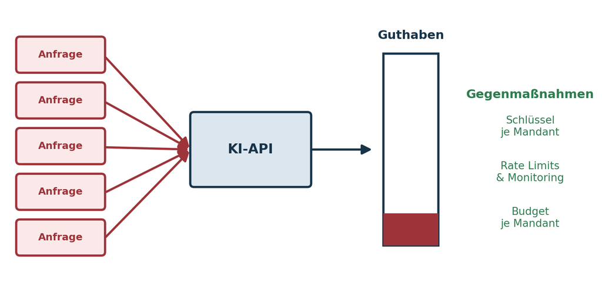

## Zusammenfassung: Reifegrad der KI-Governance

1. Ad-hoc-Governance
2. Grundlegende Strukturen und Prozesse etablieren
3. Über die Grundlagen hinausgehen
4. Erweitern und reifen
5. Eingebettete und einflussreiche Governance

„Resilienz ist die neue Vertrauenswährung der KI-Welt.“

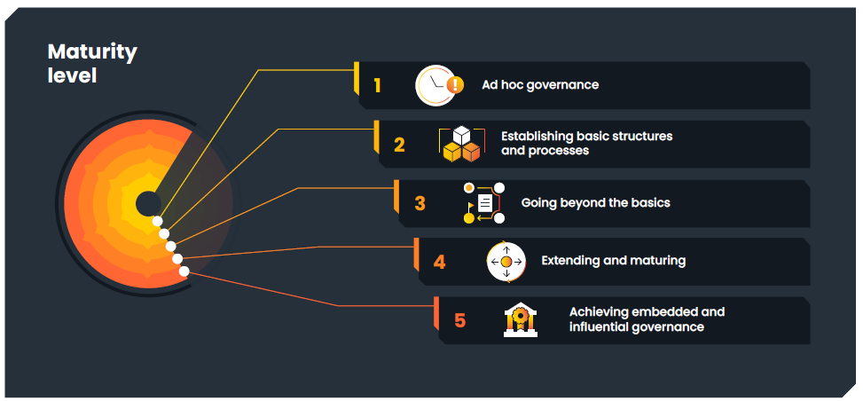

## Übung: Gandalf AI

gandalf.lakera.ai

Entlockt dem Modell über mehrere Level ein geschütztes Passwort.

- Welche Abwehrmechanismen erkennt ihr?
- Was bedeutet das für Prompt-Poisoning und die Resilienz von KI-Anwendungen?

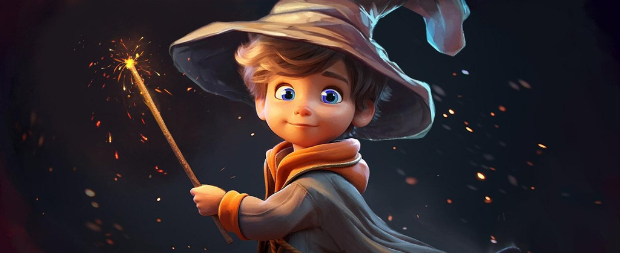

## Ausblick auf Sitzung 10

**Resilienz der Zukunft**

- Quantencomputing – wenn Vertrauen rückwirkend bricht
- Autonome Systeme – wenn Systeme selbst reagieren
- Gesellschaft & Ethik – wenn niemand allein verantwortlich ist
- Übung: Resilienz im Jahr 2035

## Material

Kapitel zum Termin · Glossar · Quellen